# Analiza Wydajności

Maksymilian Mazur

11 sierpnia 2017

## Zarys

W skypcie **Distance_Index2** przeprowadzona została analiza dotycząca jakości otrzymywanych wyników w zależności od rozmiaru próbki dla różnych typów danych wejściowych. Wnioskiem z tamtej analizy był fakt, że niezależnie od sposobu rozproszenia danych wejściowych średnia wartość otrzymywanego *Indeksu Distance* była bardzo bliska wartości rzeczywistej. Naturalną kontynuacją owej analizy jest odpowiedź na pytanie - czy bardziej opłacalne jest wielokrotne liczenie indeksu na niewielkiej próbce, czy zwiększenie rozmiaru próbki kosztem liczby powtórzeń.

W celu odpowiedzenia na to pytanie przeprowadzona została poniższa analiza. W celu przyśpieszenia testów zmodyfikowana została funkcja do wyznaczania indeksu distance. Wartość rozkładu teoretycznego jest wyliczana raz dla każdego zboru danych, a następnie przekazywana funkcji jako argument:

```r
IDistFULL <- vector(mode="numeric", length=0)
calcDistanceIndexTest <- function(coordsCategoryDF, region, theoreticalSample, empiricalSample, numberOfSamples){

  for (i in 1:numberOfSamples){
    n <- nrow(coordsCategoryDF)
    nCompanies <- min(empiricalSample,n)
    index<-sample(1:n, nCompanies, replace = FALSE)
    IDistTotal <-  mean(dist(as.matrix(coordsCategoryDF[index,c(1,2)])))/totalTheoreticalDistance
    IDistFULL <<- c(IDistFULL, IDistTotal)
  }
}
```

# Zbiory Testowe.

```r
library(tidyr)
library(SPAG)
library(R.utils)
setwd("C:/Users/Max/Desktop/TestEmpiryczny")
dane<-read.csv("geoloc data.csv", header=TRUE, sep=";", dec=".")

ShapefileDF<-as.data.frame(MapPoland)
region<-MapPoland
newCoordinateSystem<-"+proj=longlat +datum=WGS84"
region<-spTransform(region, CRS(newCoordinateSystem))
mapDF <- fortify(region)

TestCompanies1 <- dane[dane$SEK_PKD7 %in% c("C"),c(23,24)] #  Kategoria C 1327 firm
TestCompanies2 <- dane[dane$SEK_PKD7 %in% c("C", "M", "Q","S"),c(23,24)]
TestCompanies3 <- dane[dane$SEK_PKD7 %in% c("C", "M", "Q","S", "G", "O"),c(23,24)]
TestCompanies4 <- dane[dane$SEK_PKD7 %in% c("A"),c(23,24)]

df1 <- as.data.frame(cbind(TestCompanies1[1:275,1]-6,TestCompanies1[1:275,2]+2))
df2 <- TestCompanies1[276:nrow(TestCompanies1),c(1,2)]
names(df1) <- names(df2)
TestCompanies5 <- rbind(df1,df2)

df1 <- as.data.frame(cbind(TestCompanies2[1:1002,1]-6,TestCompanies2[1:1002,2]+2))
df2 <- TestCompanies2[1003:nrow(TestCompanies2),c(1,2)]
names(df1) <- names(df2)
TestCompanies6 <- rbind(df1,df2)

df1 <- as.data.frame(cbind(TestCompanies3[1:2003,1]-6,TestCompanies3[1:2003,2]+2))
df2 <- TestCompanies3[2004:nrow(TestCompanies3),c(1,2)]
names(df1) <- names(df2)
TestCompanies7 <- rbind(df1,df2)

df1 <- as.data.frame(cbind(TestCompanies4[1:4173,1]-6,TestCompanies4[1:4173,2]+2))
df2 <- TestCompanies4[4174:nrow(TestCompanies4),c(1,2)]
names(df1) <- names(df2)
TestCompanies8 <- rbind(df1,df2)

df1 <- as.data.frame(cbind(TestCompanies4[1:1000,1]-6,TestCompanies4[1:1000,2]+2))
df2 <- TestCompanies4[1001:nrow(TestCompanies4),c(1,2)]
names(df1) <- names(df2)
TestCompanies9 <- rbind(df1,df2)


df1 <- as.data.frame(cbind(TestCompanies4[1:1000,1]-6,TestCompanies4[1:1000,2]+2))
df3 <- as.data.frame(cbind(TestCompanies4[1001:1200,1]-3,TestCompanies4[1001:1200,2]-1))
df2 <- TestCompanies4[1201:nrow(TestCompanies4),c(1,2)]
names(df1) <- names(df2)
names(df3) <- names(df2)
TestCompanies10 <- rbind(df1,df2,df3)




CompaniesList <- list(TestCompanies4,
                      TestCompanies5,
                      TestCompanies6,
                      TestCompanies7,
                      TestCompanies8,
                      TestCompanies9,
                      TestCompanies10)
```

## Testy

W celu wyznaczenia optymalnego stosunki liczebności próbki/ilości próbkowań ustawiłem czas próbkowania na 30 sekund. W tym czasie dla każdego zbioru i dla każdej liczności próbkowania wykonywana była maksymalna ilość próbkowania, a następnie wynik był uśredniany. Taka średnia była następnie traktowana jako jedna obserwacja. Dla każdej liczebności próbkowania zebrałem 90 obserwacji, które były następnie analizowane.

Czas próbkowania został ustawiony na 30 sekund, gdyż wówczas całkowite wyliczenie indeksu SPAG nie powinno przekroczyć jednej minuty.

```r
IDistFULL <- vector(mode="numeric", length=0)
DistFULLList <- list()
ResultList <- vector(mode="list", length=3)
names(ResultList) <- c("200", "500", "1000")
finalList <- list()

for (zbior in 1:length(CompaniesList)){
  nCompanies <- nrow(as.data.frame(CompaniesList[zbior]))
  theoreticalCompanies <- spsample(MapPoland, nCompanies, type="regular", offset = c(0,0))
  totalTheoreticalDistance <- mean(dist(as.matrix(theoreticalCompanies@coords)))

  for (licznoscc in c(200,500,1000)){
    for (i in 1:45){

      res <- try(
evalWithTimeout(calcDistanceIndexTest(as.data.frame(CompaniesList[zbior]), MapPoland, theoreticalSample=totalTheoreticalDistance, empiricalSample=licznoscc, numberOfSamples=100000), timeout =30, onTimeout="silent")
      )
      if(inherits(res, "try-error"))
      {
        DistFULLList <- append(DistFULLList, mean(IDistFULL))
        IDistFULL <- vector(mode="numeric", length=0)
        next
      }
    }
  ResultList[[as.character(licznoscc)]] <- rapply(DistFULLList,c)
  DistFULLList <- list()
}

  nazwa <- paste('testWydajnosci','Zbior',zbior, sep='')
  doZapisu <- paste0("save(","ResultList",", file='C:/Users/Max/Desktop/TestWydajnosci/", nazwa, ".rda' )")
  eval(parse(text=doZapisu))

  ResultList <- vector(mode="list", length=3)
  names(ResultList) <- c("200", "500", "1000")
}
```

## Wyniki

```r
load('C:/Users/Max/Desktop/TestWydajnosci/testWydajnosciZbior1.rda')
ResultListTemp <- ResultList
load('C:/Users/Max/Desktop/TestWydajnosci2/testWydajnosciZbior1.rda')
#ResultList1 <- sapply(ResultList,function(x){x})
ResultList1 <- mapply(c,ResultList,ResultListTemp)
ResultList1df <- stack(as.data.frame(ResultList1))
ResultList1df$ind <- factor(as.factor(ResultList1df$ind),c("200", "500", "1000"))

load('C:/Users/Max/Desktop/TestWydajnosci/testWydajnosciZbior2.rda')
ResultListTemp <- ResultList
load('C:/Users/Max/Desktop/TestWydajnosci2/testWydajnosciZbior2.rda')
#ResultList2 <- sapply(ResultList,function(x){x})
ResultList2 <- mapply(c,ResultList,ResultListTemp)
ResultList2df <- stack(as.data.frame(ResultList2))
ResultList2df$ind <- factor(as.factor(ResultList2df$ind),c("200", "500", "1000"))

load('C:/Users/Max/Desktop/TestWydajnosci/testWydajnosciZbior3.rda')
ResultListTemp <- ResultList
load('C:/Users/Max/Desktop/TestWydajnosci2/testWydajnosciZbior3.rda')
#ResultList3 <- sapply(ResultList,function(x){x})
ResultList3 <- mapply(c,ResultList,ResultListTemp)
ResultList3df <- stack(as.data.frame(ResultList3))
ResultList3df$ind <- factor(as.factor(ResultList3df$ind),c("200", "500", "1000"))

load('C:/Users/Max/Desktop/TestWydajnosci/testWydajnosciZbior4.rda')
ResultListTemp <- ResultList
load('C:/Users/Max/Desktop/TestWydajnosci2/testWydajnosciZbior4.rda')
#ResultList4 <- sapply(ResultList,function(x){x})
ResultList4 <- mapply(c,ResultList,ResultListTemp)
ResultList4df <- stack(as.data.frame(ResultList4))
ResultList4df$ind <- factor(as.factor(ResultList4df$ind),c("200", "500", "1000"))

load('C:/Users/Max/Desktop/TestWydajnosci/testWydajnosciZbior5.rda')
ResultListTemp <- ResultList
load('C:/Users/Max/Desktop/TestWydajnosci2/testWydajnosciZbior5.rda')
#ResultList5 <- sapply(ResultList,function(x){x})
ResultList5 <- mapply(c,ResultList,ResultListTemp)
ResultList5df <- stack(as.data.frame(ResultList5))
ResultList5df$ind <- factor(as.factor(ResultList5df$ind),c("200", "500", "1000"))

load('C:/Users/Max/Desktop/TestWydajnosci/testWydajnosciZbior6.rda')
ResultListTemp <- ResultList
load('C:/Users/Max/Desktop/TestWydajnosci2/testWydajnosciZbior6.rda')
#ResultList6 <- sapply(ResultList,function(x){x})
ResultList6 <- mapply(c,ResultList,ResultListTemp)
ResultList6df <- stack(as.data.frame(ResultList6))
ResultList6df$ind <- factor(as.factor(ResultList6df$ind),c("200", "500", "1000"))

load('C:/Users/Max/Desktop/TestWydajnosci/testWydajnosciZbior7.rda')
ResultListTemp <- ResultList
load('C:/Users/Max/Desktop/TestWydajnosci2/testWydajnosciZbior7.rda')
#ResultList7 <- sapply(ResultList,function(x){x})
ResultList7 <- mapply(c,ResultList,ResultListTemp)
ResultList7df <- stack(as.data.frame(ResultList7))
ResultList7df$ind <- factor(as.factor(ResultList7df$ind),c("200", "500", "1000"))
```

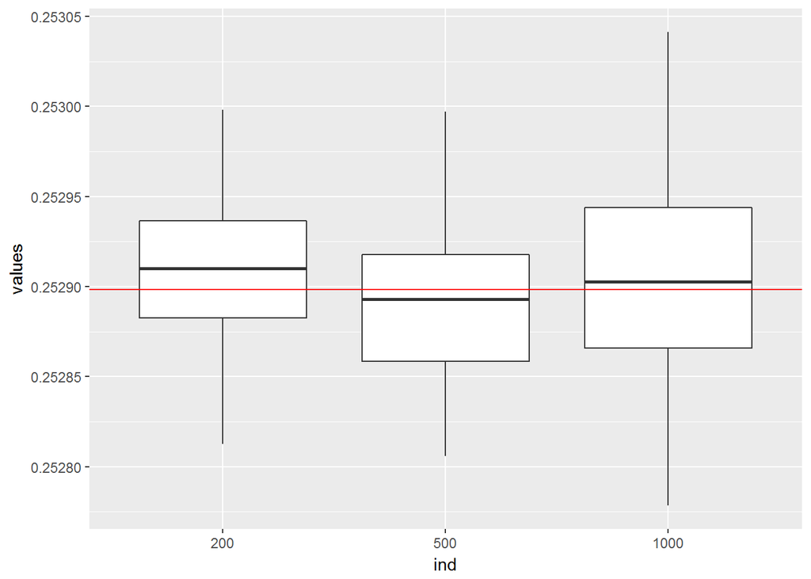

```r
library(ggplot2)
load('C:/Users/Max/Desktop/TestWydajnosci2/WynikiDokladneIndeksuSPAG.rda')

ggplot() +
  geom_boxplot(data=ResultList1df,  mapping=aes(ind, values)) +
  geom_hline(yintercept = WynikiDokladneIndeksuSPAG[1,1], col="red")
```

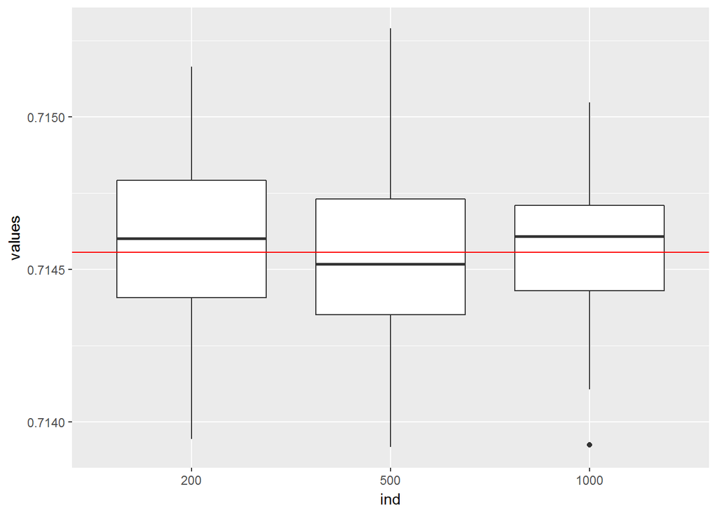

```r
ggplot() +
  geom_boxplot(data=ResultList2df,  mapping=aes(ind, values)) +
  geom_hline(yintercept = WynikiDokladneIndeksuSPAG[2,1], col="red")
```

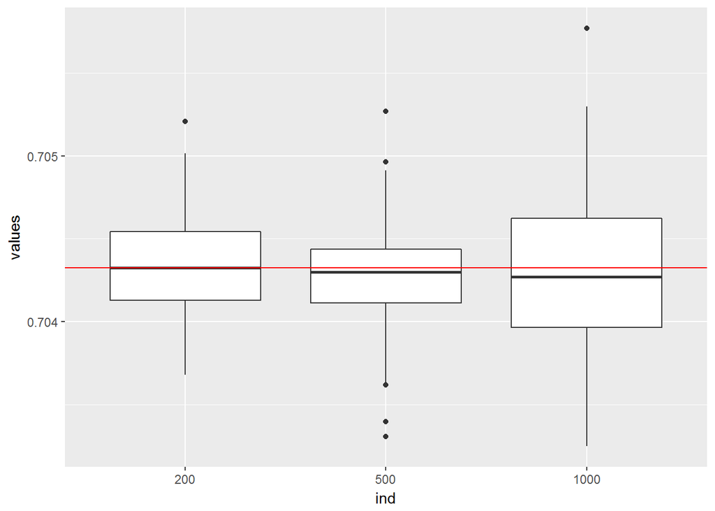

```r
ggplot() +
  geom_boxplot(data=ResultList3df,  mapping=aes(ind, values)) +
  geom_hline(yintercept = WynikiDokladneIndeksuSPAG[3,1], col="red")
```

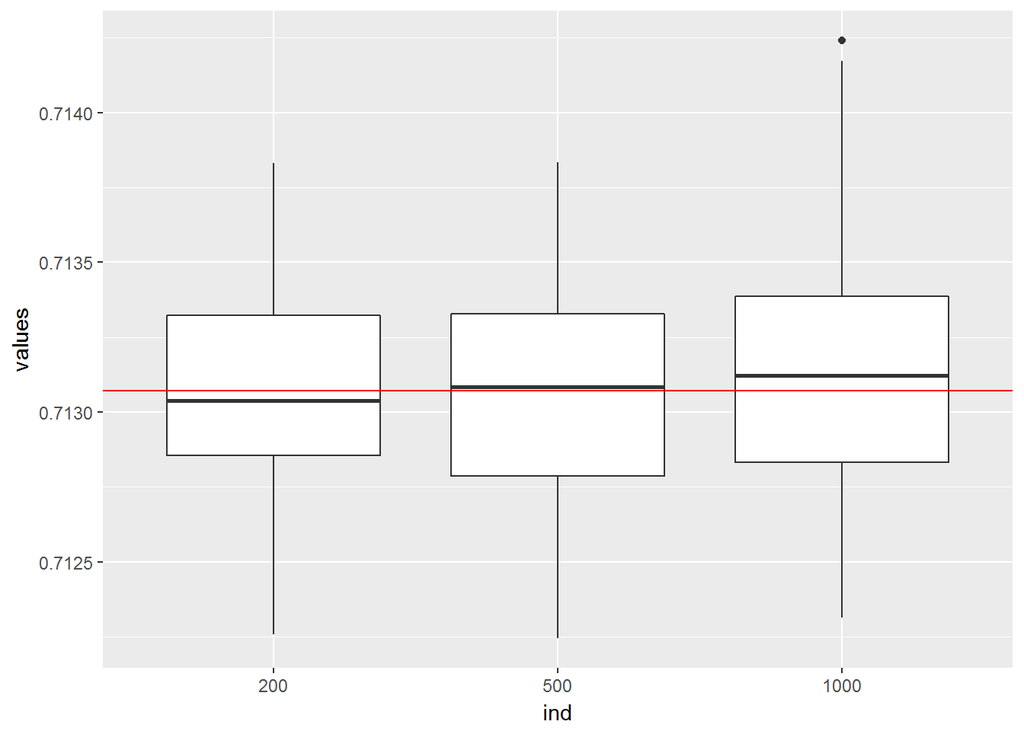

```r
ggplot() +
  geom_boxplot(data=ResultList4df,  mapping=aes(ind, values)) +
  geom_hline(yintercept = WynikiDokladneIndeksuSPAG[4,1], col="red")
```

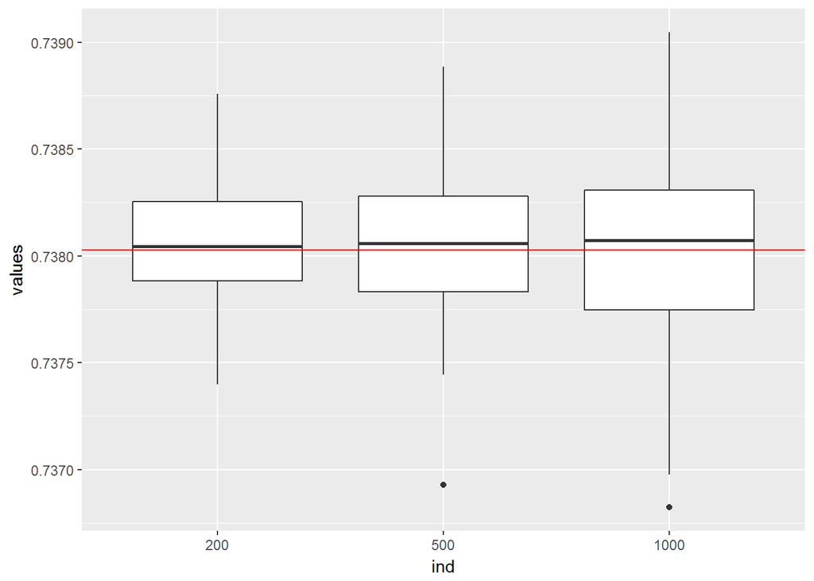

```r
ggplot() +
  geom_boxplot(data=ResultList5df,  mapping=aes(ind, values)) +
  geom_hline(yintercept = WynikiDokladneIndeksuSPAG[5,1], col="red")
```

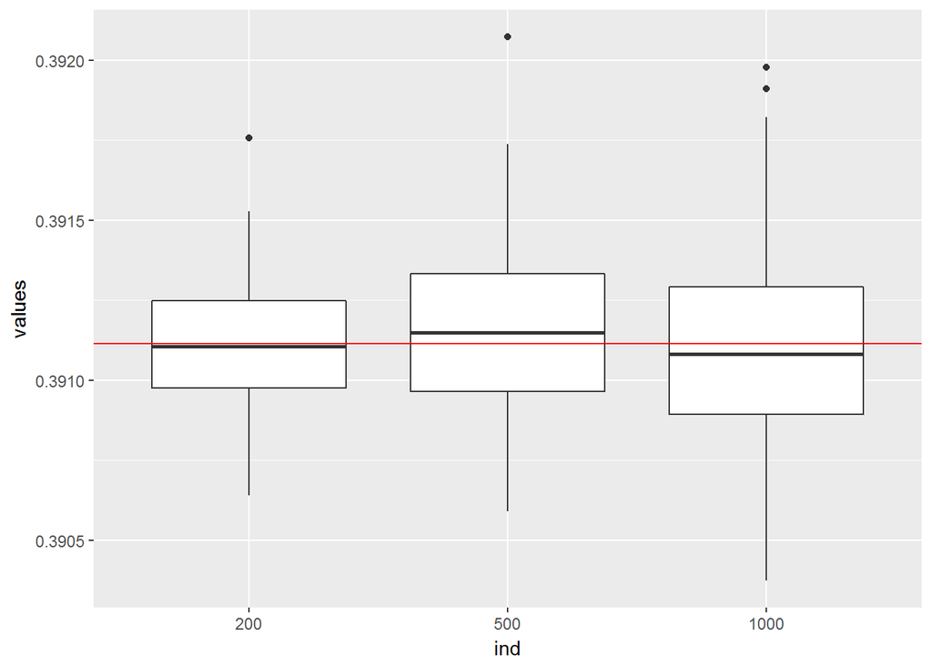

```r
ggplot() +
  geom_boxplot(data=ResultList6df,  mapping=aes(ind, values)) +
  geom_hline(yintercept = WynikiDokladneIndeksuSPAG[6,1], col="red")
```

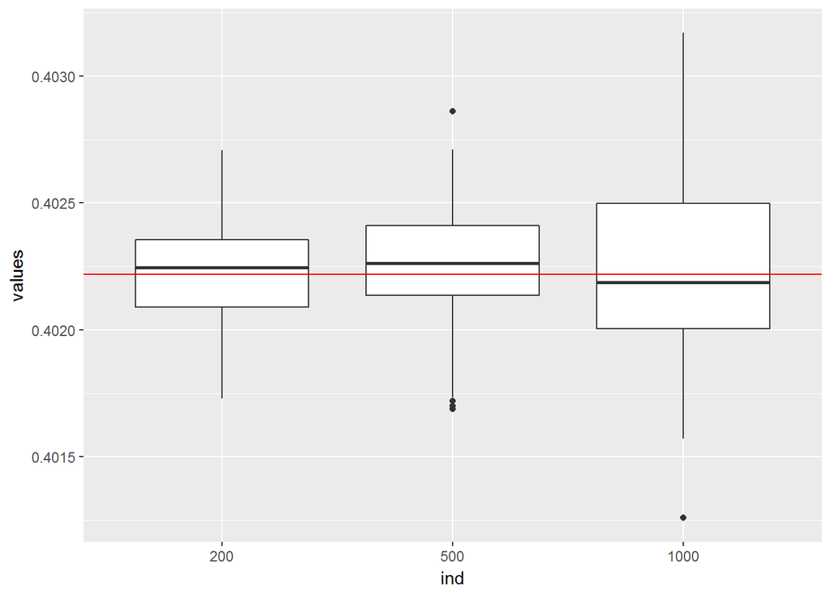

```r
ggplot() +
  geom_boxplot(data=ResultList7df,  mapping=aes(ind, values)) +
  geom_hline(yintercept = WynikiDokladneIndeksuSPAG[7,1], col="red")
```

Kolejnym krokiem było sprawdzenie współczynnika zmienności:

```r
df <- rbind(
  apply(ResultList1, MARGIN=2, FUN=function(x){sd(x)/mean(x)}),
  apply(ResultList2, MARGIN=2, FUN=function(x){sd(x)/mean(x)}),
  apply(ResultList3, MARGIN=2, FUN=function(x){sd(x)/mean(x)}),
  apply(ResultList4, MARGIN=2, FUN=function(x){sd(x)/mean(x)}),
  apply(ResultList5, MARGIN=2, FUN=function(x){sd(x)/mean(x)}),
  apply(ResultList6, MARGIN=2, FUN=function(x){sd(x)/mean(x)}),
  apply(ResultList7, MARGIN=2, FUN=function(x){sd(x)/mean(x)})
)
df
```

```
##               200          500         1000
## [1,] 0.0001583278 0.0001715006 0.0002152754
## [2,] 0.0003854918 0.0003918646 0.0003050280
## [3,] 0.0004514712 0.0004640889 0.0006512376
## [4,] 0.0004440474 0.0004924806 0.0005682215
## [5,] 0.0003643126 0.0004547068 0.0005634729
## [6,] 0.0005463355 0.0006751493 0.0008498086
## [7,] 0.0004991406 0.0005717426 0.0008585738
```

Okazuje się, że najmniejszą zmienność miały obserwacje otrzymane przy najmniejszym próbkowaniu:

```r
a <- apply(df,1,function(x){print(names(which(x==min(x))))})
```

```
## [1] "200"
## [1] "1000"
## [1] "200"
## [1] "200"
## [1] "200"
## [1] "200"
## [1] "200"
```

```r
mat <- matrix(rbind(
  apply(ResultList1, MARGIN=2, FUN=function(x){mean(x)}),
  apply(ResultList2, MARGIN=2, FUN=function(x){mean(x)}),
  apply(ResultList3, MARGIN=2, FUN=function(x){mean(x)}),
  apply(ResultList4, MARGIN=2, FUN=function(x){mean(x)}),
  apply(ResultList5, MARGIN=2, FUN=function(x){mean(x)}),
  apply(ResultList6, MARGIN=2, FUN=function(x){mean(x)}),
  apply(ResultList7, MARGIN=2, FUN=function(x){mean(x)})
), nrow=7)

for (i in 1:7){
  print(abs((mat[i,]-WynikiDokladneIndeksuSPAG[i,]))*100)
  mat[i,] <- abs((mat[i,]-WynikiDokladneIndeksuSPAG[i,]))
}
```

```
## [1] 0.0012153742 0.0006612247 0.0006870211
## [1] 0.0034387475 0.0014497433 0.0008914752
## [1] 0.001418941 0.004784074 0.003757671
## [1] 1.302044e-03 3.119922e-05 7.568322e-03
## [1] 0.003720861 0.003062493 0.003180615
## [1] 0.0004670817 0.0036081221 0.0021366794
## [1] 0.001467415 0.002975613 0.001924403
```

```r
mat <- as.data.frame(mat)
names(mat) <- c("200", "500", "1000")
a <- apply(mat,1,function(x){print(names(which(x==min(x))))})
```

```
## [1] "500"
## [1] "1000"
## [1] "200"
## [1] "500"
## [1] "500"
## [1] "200"
## [1] "200"
```